# Day 3-B Activity (Decision Trees and Random Forests)

# Live Coding

Goal: Classify likelihood of having a heart attack based on demographics (age, sex) and health variables (type of chest pain, resting blood pressure, cholesterol, fasting blood sugar, resting electrocardiographic results, maximum heart rate, exercise induced angina, etc.). Compare performance of fully grown trees, pruned trees, trees grown with a stopping parameter, and random forests.

## Load Packages

```r
if (!require("tidyverse")) {install.packages("tidyverse"); require("tidyverse")}
if (!require("caret")) {install.packages("caret"); require("caret")}
if (!require("tidymodels")) {install.packages("tidymodels"); require("tidymodels")}
if (!require("summarytools")) {install.packages("summarytools"); require("summarytools")}
if (!require("psych")) {install.packages("psych"); require("psych")}
if (!require("coefplot")) {install.packages("coefplot"); require("coefplot")}
if (!require("pROC")) {install.packages("pROC"); require("pROC")}
if (!require("rpart")) {install.packages("rpart"); require("rpart")}
if (!require("randomForest")) {install.packages("randomForest"); require("randomForest")}
if (!require("AppliedPredictiveModeling")) {install.packages("AppliedPredictiveModeling"); require("AppliedPredictiveModeling")}
```

## Load data

```r
heart <- read_csv("https://bit.ly/amlr-heart", col_types = "dffddffdfdiiif")
```

## Split into train/test sets

```r
set.seed(2021)
trainIndex <- createDataPartition(heart$output, p = 0.8, list = FALSE)
heart_train <- heart[trainIndex, ]
heart_test <- heart[-trainIndex, ]

# check to see that data splits were correct
dim(heart_train)
```

```
## [1] 243  14
```

```r
dim(heart_test)
```

```
## [1] 60 14
```

## Create Training Recipe

```r
heart_recipe <-
  heart_train %>%
  recipe(output ~ .) %>%
  step_mutate(output = factor(output, levels = c(0, 1), labels = c("low_risk", "high_risk"))) %>%
  step_dummy(all_nominal_predictors(), one_hot = TRUE)

# prep and bake training and test data for later (model evaluation)
heart_train_baked <-
  heart_recipe %>%
  prep(training = heart_train) %>%
  bake(new_data = heart_train)

heart_test_baked <-
  heart_recipe %>%
  prep(training = heart_train) %>%
  bake(new_data = heart_test)
```

## Set up Resampling Methods

```r
# let's use 5-fold cross-validation, repeated 3 times

# set train control
heart_control <- trainControl(method = 'repeatedcv',
                              number = 5,
                              repeats = 3)
```

## Full Tree Fit

To illustrate overfitting (if we don’t stop trees from growing), we’ll fit an un-pruned tree with no stopping criteria, with a minsplit of 2 (minimum 2 observations needed to create a split) and minbucket of 1 (minimum number observations per node). Note that we would never want to do this in practice; this is just for teaching illustration!

```r
cpgrid_full <- expand.grid(cp = 0)
full_tree <- train(heart_recipe, data = heart_train,
                   method = 'rpart',
                   trControl = heart_control,
                   tuneGrid = cpgrid_full,
                   control = rpart.control(minsplit = 2, minbucket = 1))

full_tree
```

```
## CART
##
## 243 samples
##  13 predictor
##   2 classes: 'low_risk', 'high_risk'
##
## Recipe steps: mutate, dummy
## Resampling: Cross-Validated (5 fold, repeated 3 times)
## Summary of sample sizes: 195, 195, 194, 193, 195, 195, ...
## Resampling results:
##
##   Accuracy   Kappa
##   0.7091916  0.4125986
##
## Tuning parameter 'cp' was held constant at a value of 0
```

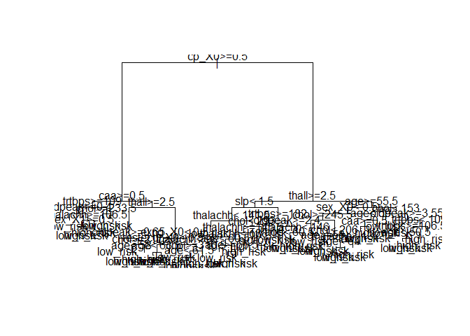

```r
plot(full_tree$finalModel)
text(full_tree$finalModel)
```

## Classification Accuracy: Fully Grown Trees

Let’s calculate how well it does on the training set, relative to the test set. This gives us a sense of how over-fit the data is on our training set

```r
full_tree_train_preds <- predict(full_tree, newdata = heart_train)
full_tree_test_preds <- predict(full_tree, newdata = heart_test)
full_tree_train_prob <- predict(full_tree, newdata = heart_train, type = "prob")
full_tree_test_prob <- predict(full_tree, newdata = heart_test, type = "prob")

# Collect all predicted and trusted labels in a dataframe (for {yardstick})
collected_labels_train <- bind_cols(
  full_tree_train_prob,
  true = heart_train_baked$output,
  pred = full_tree_train_preds)

collected_labels_test <- bind_cols(
  full_tree_test_prob,
  true = heart_test_baked$output,
  pred = full_tree_test_preds)

cm_train <- conf_mat(collected_labels_train, truth = true, estimate = pred)
cm_test <- conf_mat(collected_labels_test, truth = true, estimate = pred)
summary(cm_train)
```

| .metric | .estimator | .estimate |
| --- | --- | --- |
| accuracy | binary | 1.0000000 |
| kap | binary | 1.0000000 |
| sens | binary | 1.0000000 |
| spec | binary | 1.0000000 |
| ppv | binary | 1.0000000 |
| npv | binary | 1.0000000 |
| mcc | binary | 1.0000000 |
| j_index | binary | 1.0000000 |
| bal_accuracy | binary | 1.0000000 |
| detection_prevalence | binary | 0.4567901 |

[output cut: 3 more lines]

```r
summary(cm_test)
```

| .metric | .estimator | .estimate |
| --- | --- | --- |
| accuracy | binary | 0.8166667 |
| kap | binary | 0.6357616 |
| sens | binary | 0.8888889 |
| spec | binary | 0.7575758 |
| ppv | binary | 0.7500000 |
| npv | binary | 0.8928571 |
| mcc | binary | 0.6446584 |
| j_index | binary | 0.6464646 |
| bal_accuracy | binary | 0.8232323 |
| detection_prevalence | binary | 0.5333333 |

[output cut: 3 more lines]

```r
roc_auc(collected_labels_train, truth = true, high_risk, event_level = "second")
```

| .metric | .estimator | .estimate |
| --- | --- | --- |
| roc_auc | binary | 1 |

```r
roc_auc(collected_labels_test, truth = true, high_risk, event_level = "second")
```

| .metric | .estimator | .estimate |
| --- | --- | --- |
| roc_auc | binary | 0.8232323 |

## Reduce Overfitting by Pruning the Tree

```r
pruned_tree <- train(heart_recipe, data = heart_train,
                     method = "rpart",
                     tuneLength = 20,
                     trControl = heart_control)

pruned_tree
```

```
## CART
##
## 243 samples
##  13 predictor
##   2 classes: 'low_risk', 'high_risk'
##
## Recipe steps: mutate, dummy
## Resampling: Cross-Validated (5 fold, repeated 3 times)
## Summary of sample sizes: 194, 194, 195, 195, 194, 195, ...
## Resampling results across tuning parameters:
##
##   cp          Accuracy   Kappa
##   0.00000000  0.7334943  0.4623429
##   0.02560455  0.7405238  0.4696045
##   0.05120910  0.7283027  0.4488017
##   0.07681366  0.7241077  0.4442760
##   0.10241821  0.7281893  0.4492482
##   0.12802276  0.7281893  0.4492482
##   0.15362731  0.7281893  0.4492482
##   0.17923186  0.7281893  0.4492482
##   0.20483642  0.7281893  0.4492482
##   0.23044097  0.7281893  0.4492482
##   0.25604552  0.7281893  0.4492482
##   0.28165007  0.7281893  0.4492482
##   0.30725462  0.7281893  0.4492482
##   0.33285917  0.7281893  0.4492482
##   0.35846373  0.7281893  0.4492482
##   0.38406828  0.7281893  0.4492482
##   0.40967283  0.7281893  0.4492482
##   0.43527738  0.7281893  0.4492482
##   0.46088193  0.7281893  0.4492482
##   0.48648649  0.6429286  0.2441652
##
## Accuracy was used to select the optimal model using the largest value.
## The final value used for the model was cp = 0.02560455.
```

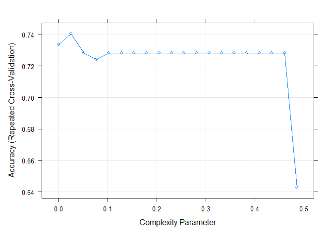

```r
plot(pruned_tree)
```

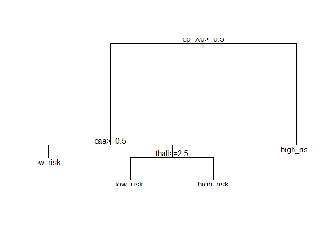

```r
plot(pruned_tree$finalModel)
text(pruned_tree$finalModel)
```

## Reduce Overfitting with Stopping Criteria

```r
early_stopped_tree <- train(heart_recipe, data = heart_train,
                            method = "rpart2",
                            tuneLength = 20,
                            trControl = heart_control)
```

```
## note: only 4 possible values of the max tree depth from the initial fit.
##  Truncating the grid to 4 .
```

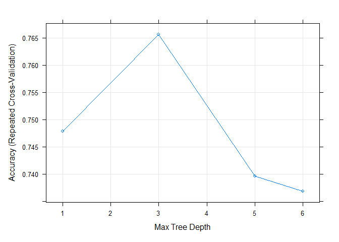

```r
plot(early_stopped_tree)
```

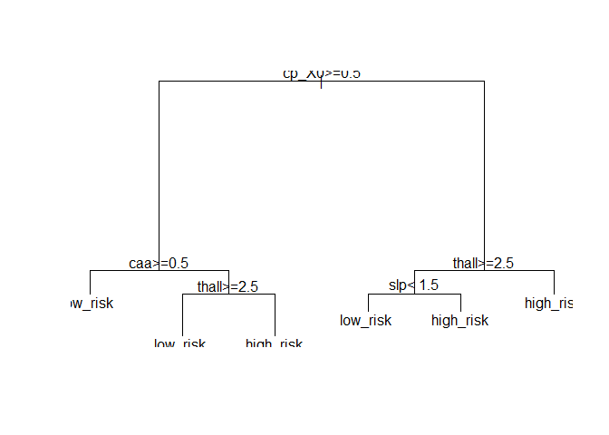

```r
plot(early_stopped_tree$finalModel)
text(early_stopped_tree$finalModel)
```

## Classification Accuracy: Pruning and Stopping Criteria

```r
pruned_tree_preds <- predict(pruned_tree, newdata = heart_test)
stopped_tree_preds <- predict(early_stopped_tree, newdata = heart_test)
pruned_tree_prob <- predict(pruned_tree, newdata = heart_test, type = "prob")
stopped_tree_prob <- predict(early_stopped_tree, newdata = heart_test, type = "prob")

# Collect all predicted and trusted labels in a dataframe (for {yardstick})
collected_labels_pruned <- bind_cols(
  pruned_tree_prob,
  true = heart_test_baked$output,
  pred = pruned_tree_preds)

collected_labels_stopped <- bind_cols(
  stopped_tree_prob,
  true = heart_test_baked$output,
  pred = stopped_tree_preds)

cm_prune <- conf_mat(collected_labels_pruned, truth = true, estimate = pred)
cm_stop <- conf_mat(collected_labels_stopped, truth = true, estimate = pred)
summary(cm_prune)
```

| .metric | .estimator | .estimate |
| --- | --- | --- |
| accuracy | binary | 0.8666667 |
| kap | binary | 0.7269625 |
| sens | binary | 0.7777778 |
| spec | binary | 0.9393939 |
| ppv | binary | 0.9130435 |
| npv | binary | 0.8378378 |
| mcc | binary | 0.7338330 |
| j_index | binary | 0.7171717 |
| bal_accuracy | binary | 0.8585859 |
| detection_prevalence | binary | 0.3833333 |

[output cut: 3 more lines]

```r
summary(cm_stop)
```

| .metric | .estimator | .estimate |
| --- | --- | --- |
| accuracy | binary | 0.8666667 |
| kap | binary | 0.7324415 |
| sens | binary | 0.8888889 |
| spec | binary | 0.8484848 |
| ppv | binary | 0.8275862 |
| npv | binary | 0.9032258 |
| mcc | binary | 0.7340855 |
| j_index | binary | 0.7373737 |
| bal_accuracy | binary | 0.8686869 |
| detection_prevalence | binary | 0.4833333 |

[output cut: 3 more lines]

```r
roc_auc(collected_labels_pruned, truth = true, high_risk, event_level = "second")
```

| .metric | .estimator | .estimate |
| --- | --- | --- |
| roc_auc | binary | 0.8563412 |

```r
roc_auc(collected_labels_stopped, truth = true, high_risk, event_level = "second")
```

| .metric | .estimator | .estimate |
| --- | --- | --- |
| roc_auc | binary | 0.9107744 |

A bit better, but not by too much. In other datasets you might see a bigger effect. How can we improve more?

## Random Forests

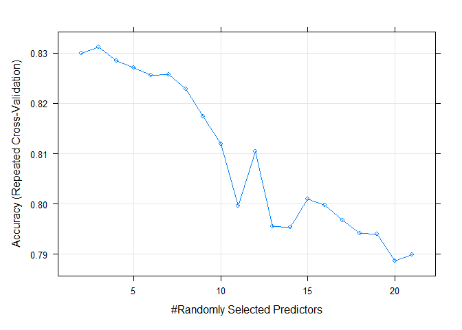

```r
rf_fit <- train(heart_recipe, data = heart_train,
                method = "rf",
                tuneLength = 20,
                trControl = heart_control)

plot(rf_fit)
```

## Random Forests Accuracy

```r
rf_preds <- predict(rf_fit, newdata = heart_test)
rf_prob <- predict(rf_fit, newdata = heart_test, type = "prob")

# Collect all predicted and trusted labels in a dataframe (for {yardstick})
collected_labels_rf <- bind_cols(
  rf_prob,
  true = heart_test_baked$output,
  pred = rf_preds)

cm_rf <- conf_mat(collected_labels_rf, truth = true, estimate = pred)
summary(cm_rf)
```

| .metric | .estimator | .estimate |
| --- | --- | --- |
| accuracy | binary | 0.7500000 |
| kap | binary | 0.5065789 |
| sens | binary | 0.8518519 |
| spec | binary | 0.6666667 |
| ppv | binary | 0.6764706 |
| npv | binary | 0.8461538 |
| mcc | binary | 0.5205674 |
| j_index | binary | 0.5185185 |
| bal_accuracy | binary | 0.7592593 |
| detection_prevalence | binary | 0.5666667 |

[output cut: 3 more lines]

```r
roc_auc(collected_labels_rf, truth = true, high_risk, event_level = "second")
```

| .metric | .estimator | .estimate |
| --- | --- | --- |
| roc_auc | binary | 0.8956229 |

## What does the tree look like?

We don’t know… there are many trees, so it’s hard to gain insight, since there is not ‘one model’. Instead, we can figure out what what the ‘important variables’ are across the different trees.

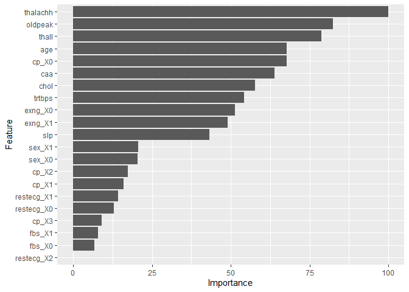

```r
ggplot(varImp(rf_fit))
```

## Hands-On Activity

Washington University conducted a clinical study to determine if biological measurements made from cerebrospinal fluid (CSF) can be used to diagnose or predict Alzheimer’s disease (Craig-Schapiro et al. 2011). These data include measurements from 333 participants (a modified version of the values used for the publication).

The first 128 columns in the dataframe represent numerical biological measurements (to be used as features). The next two columns `ahd[, 129:130]` are nominal features (male sex {yes, no}; genotype {E2E2, E2E3, E2E4, E3E3, E3E4, E4E4}). The last column `ahd[, 131]` is the categorical label representing presence/absense of Alzheimer’s Disease (diagnosis {control, impaired}).

1. Split your data into 80% training and 20% test
2. Create your training recipe, using one-hot encoding for categorical variables.
3. Fit a random forest model with 5-fold cross-validation. Use a tuning grid with 10 values.
4. Estimate Accuracy and Kappa in the training and testing sets
5. Examine and plot the model’s variable importance.

**BONUS 1**: Construct a confusion matrix and ROC curve for the model.

**BONUS 2**: Fit a pruned decision tree on the data with 5-fold cross-validation. Compare classification metrics (accuracy, kappa, AUROC) between the random forests and pruned tree models in the testing sets. Which performs better, and why?

```r
ahd <- read.csv("https://bit.ly/amlr-ahd", stringsAsFactors = TRUE)
```

# Answer key

**Click here to view the answer key to the hands-on activity**

## 1. Split your data into 80% training and 20% test

```r
set.seed(2021)
trainIndex <- createDataPartition(ahd$diagnosis, p = 0.8, list = FALSE)
ahd_train <- ahd[trainIndex, ]
ahd_test <- ahd[-trainIndex, ]

# check to see that data splits were correct
dim(ahd_train)
```

```
## [1] 267 131
```

```r
dim(ahd_test)
```

```
## [1]  66 131
```

## Create your training recipe, using one-hot encoding for categorical variables.

```r
ahd_recipe <-
  ahd_train %>%
  recipe(diagnosis ~ .) %>%
  step_dummy(all_nominal_predictors(), one_hot = TRUE)

ahd_test_baked <-
  ahd_recipe %>%
  prep(training = ahd_train) %>%
  bake(new_data = ahd_test)
```

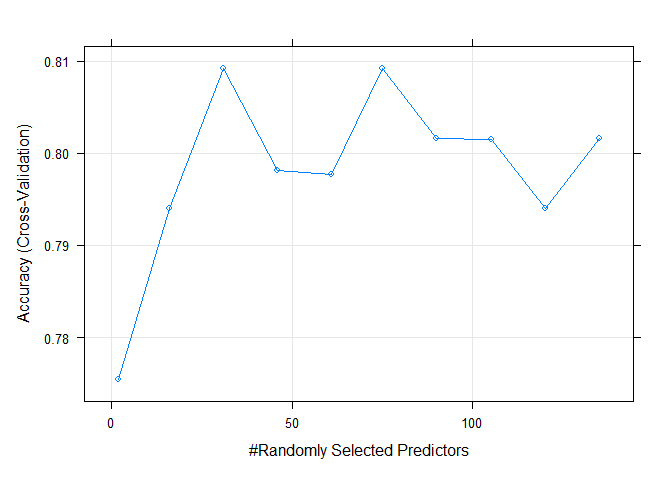

```r
ahd_control <- trainControl(method = 'cv',
                            number = 5)

rf_fit_ahd <- train(ahd_recipe, data = ahd_train,
                    method = "rf",
                    tuneLength = 10,
                    trControl = ahd_control)

plot(rf_fit_ahd)
```

## Estimate Accuracy and Kappa in the training and testing sets

```r
rf_fit_ahd$results %>% print()
```

```
##    mtry  Accuracy     Kappa AccuracySD    KappaSD
## 1     2 0.7754421 0.2557094 0.03571877 0.11881208
## 2    16 0.7940305 0.3950937 0.03434971 0.10575832
## 3    31 0.8091974 0.4391587 0.04713395 0.14227965
## 4    46 0.7980917 0.4082341 0.02815271 0.10105830
## 5    61 0.7976644 0.4096797 0.01654996 0.04131924
## 6    75 0.8092001 0.4446710 0.02202283 0.07373212
## 7    90 0.8015831 0.4229423 0.02751697 0.08217028
## 8   105 0.8015105 0.4212557 0.00937599 0.05520194
## 9   120 0.7939633 0.4016184 0.02977487 0.10806466
## 10  135 0.8016503 0.4219896 0.01922351 0.06897673
```

```r
ahd_pred <- predict(rf_fit_ahd, newdata = ahd_test)
postResample(pred = ahd_pred, obs = ahd_test_baked$diagnosis)
```

```
##  Accuracy     Kappa
## 0.8636364 0.6086957
```

## Examine and plot the model’s variable importance.

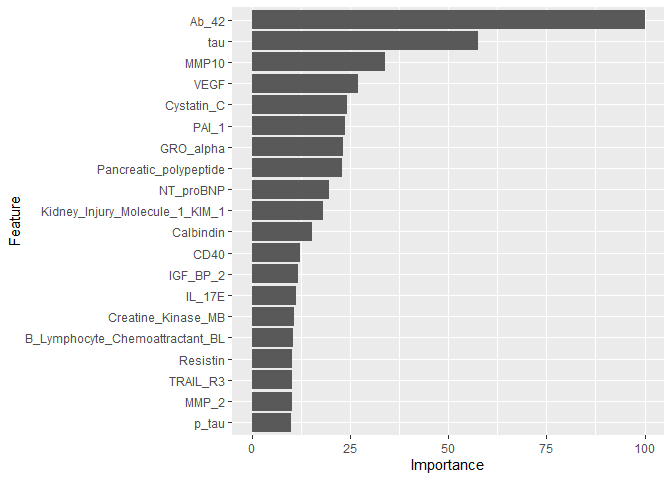

```r
ggplot(varImp(rf_fit_ahd), top = 20)
```

## **BONUS 1**: Construct a confusion matrix and ROC curve for the model.

```r
rf_ahd_preds <- predict(rf_fit_ahd, newdata = ahd_test)
rf_ahd_prob <- predict(rf_fit_ahd, newdata = ahd_test, type = "prob")

# Collect all predicted and trusted labels in a dataframe (for {yardstick})
collected_labels_rf_ahd <- bind_cols(
  rf_ahd_prob,
  true = ahd_test$diagnosis,
  pred = rf_ahd_preds)

cm_rf_ahd <- conf_mat(collected_labels_rf_ahd, truth = true, estimate = pred)
cm_rf_ahd
```

```
##           Truth
## Prediction Control Impaired
##   Control       47        8
##   Impaired       1       10
```

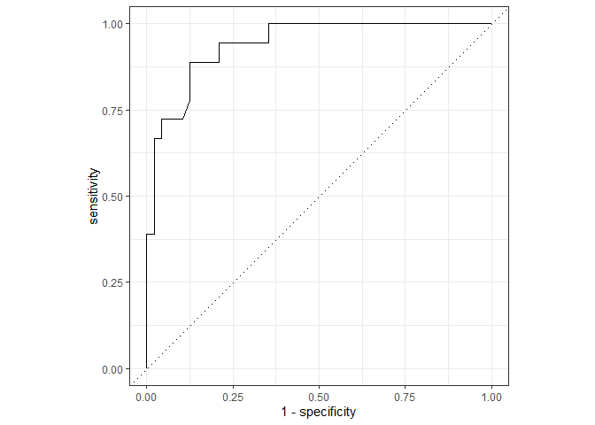

```r
roc_curve(collected_labels_rf_ahd, truth = true, Impaired, event_level = "second") %>%
  autoplot()
```

## **BONUS 2**: Fit a pruned decision tree on the data with 5-fold cross-validation. Compare classification metrics (accuracy, kappa, AUROC) between the random forests and pruned tree models in the training and testing sets. Which performs better, and why?

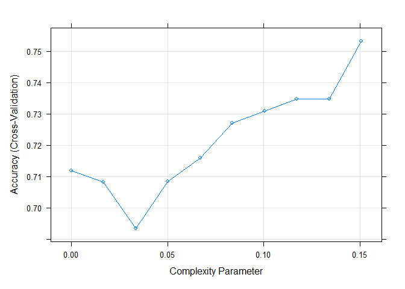

```r
pruned_fit_ahd <- train(ahd_recipe, data = ahd_train,
                        method = "rpart",
                        tuneLength = 10,
                        trControl = ahd_control)

plot(pruned_fit_ahd)
```

```r
# pruned tree training accuracy
pruned_ahd_preds <- predict(pruned_fit_ahd, newdata = ahd_test)
pruned_ahd_prob <- predict(pruned_fit_ahd, newdata = ahd_test, type = "prob")

collected_labels_pruned_ahd <- bind_cols(
  pruned_ahd_prob,
  true = ahd_test$diagnosis,
  pred = pruned_ahd_preds)
cm_pruned_ahd <- conf_mat(collected_labels_pruned_ahd, truth = true, estimate = pred)
summary(cm_pruned_ahd)
```

| .metric | .estimator | .estimate |
| --- | --- | --- |
| accuracy | binary | 0.7272727 |
| kap | binary | 0.0000000 |
| sens | binary | 1.0000000 |
| spec | binary | 0.0000000 |
| ppv | binary | 0.7272727 |
| npv | binary | NaN |
| mcc | binary | NA |
| j_index | binary | 0.0000000 |
| bal_accuracy | binary | 0.5000000 |
| detection_prevalence | binary | 1.0000000 |

[output cut: 3 more lines]

```r
roc_auc(collected_labels_pruned_ahd, truth = true, Impaired, event_level = "second")
```

| .metric | .estimator | .estimate |
| --- | --- | --- |
| roc_auc | binary | 0.5 |

```r
## rf testing accuracy
summary(cm_rf_ahd) # random forest gives higher accuracy
```

| .metric | .estimator | .estimate |
| --- | --- | --- |
| accuracy | binary | 0.8636364 |
| kap | binary | 0.6086957 |
| sens | binary | 0.9791667 |
| spec | binary | 0.5555556 |
| ppv | binary | 0.8545455 |
| npv | binary | 0.9090909 |
| mcc | binary | 0.6390097 |
| j_index | binary | 0.5347222 |
| bal_accuracy | binary | 0.7673611 |
| detection_prevalence | binary | 0.8333333 |

[output cut: 3 more lines]

```r
roc_auc(collected_labels_rf_ahd, truth = true, Impaired, event_level = "second") # random forest also gives higher AUC
```

| .metric | .estimator | .estimate |
| --- | --- | --- |
| roc_auc | binary | 0.9403935 |